# Biodiversity

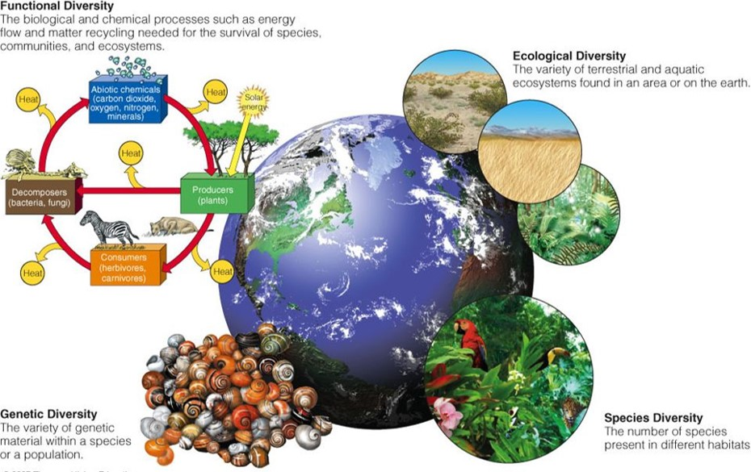

## Diversity can buffer ecological systems against change

- **Functional redundancy = multiple species may contribute to similar ecosystem roles**
- **Response diversity = species performing similar roles may respond differently to disturbance**
- Biodiversity can influence:
  - resistance = how much a system changes
  - resilience = how quickly a system recovers

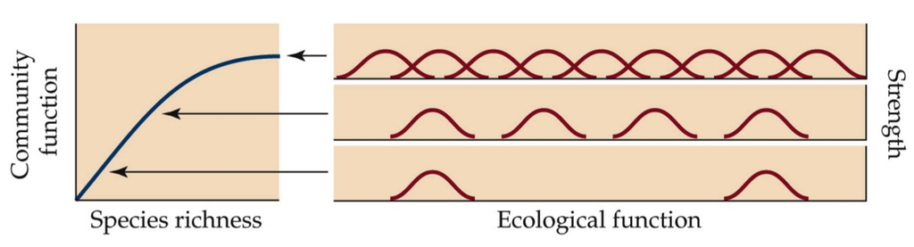

## Today’s main topic: Species diversity

- **Intricate webs of interacting organisms**
  - ~2,000,000 species are known
  - ~18,000 new species discovered per year
  - estimated >85% of species remain undescribed
- **Species diversity is only one dimension of biodiversity**
  - but it is the main focus of today
- **Humans are rapidly altering ecosystems**
  - aquatic and terrestrial
  - species losses now exceed background rates

[figure not shown]

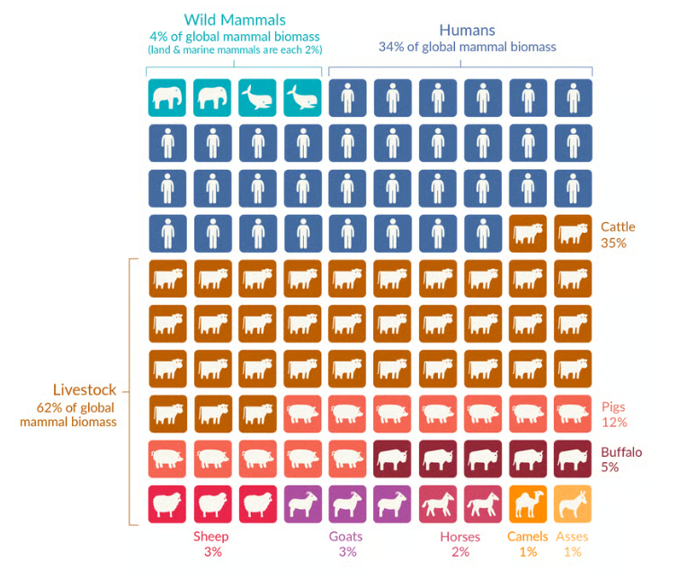

## HOW: Measuring biodiversity (e.g. Simpson’s index)

**Assumption: all species are treated as equally important**

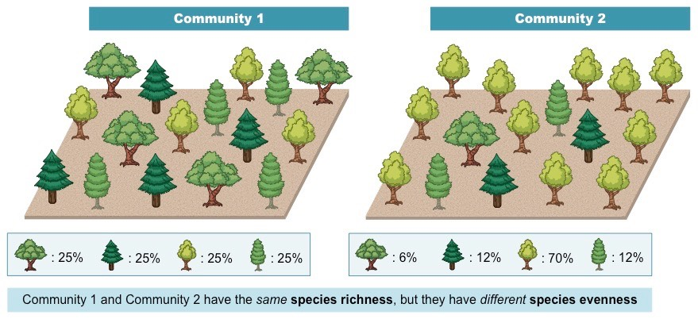

## Spatial scale matters: alpha, beta, and gamma diversity

- **Alpha diversity**
  - diversity within a local community or site
- **Beta diversity**
  - turnover or compositional difference among communities
- **Gamma diversity**
  - total diversity across the broader region
- **The question, ‘How diverse is the place?’ requires spatial context**
  - can local richness increase while regional distinctness declines?

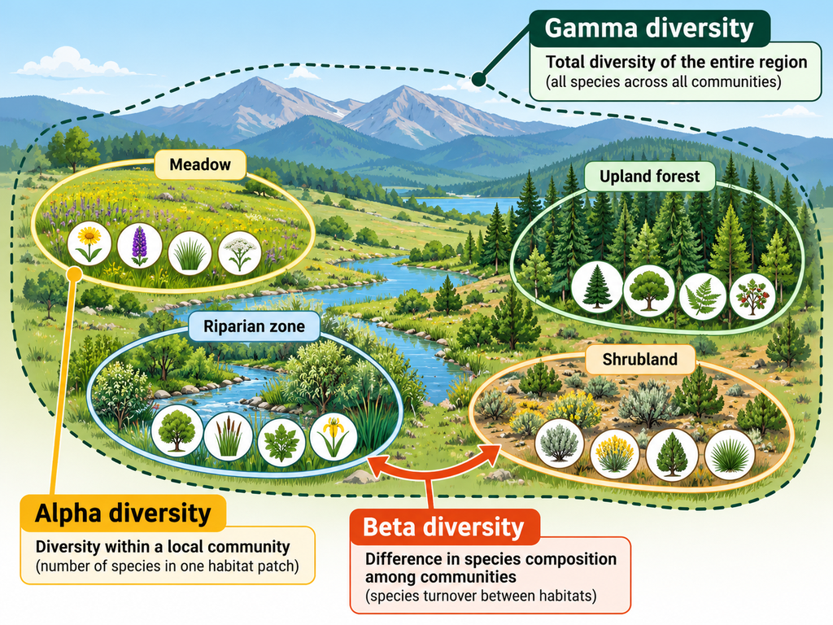

## Similar species diversity may not = same ecological function

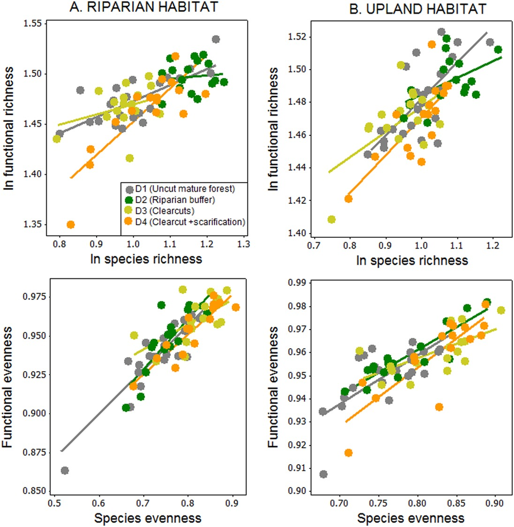

- **Richness and evenness describe species diversity**
- **But communities with similar species diversity may differ in:**
  - functional diversity
  - phylogenetic diversity
  - ecosystem function
- **Key implication:**
  - diversity indices summarize pattern
  - they do not fully tell us what organisms do
    - species identity/role matters

## WHO: Species types (native, endemic, non-native, invasive)

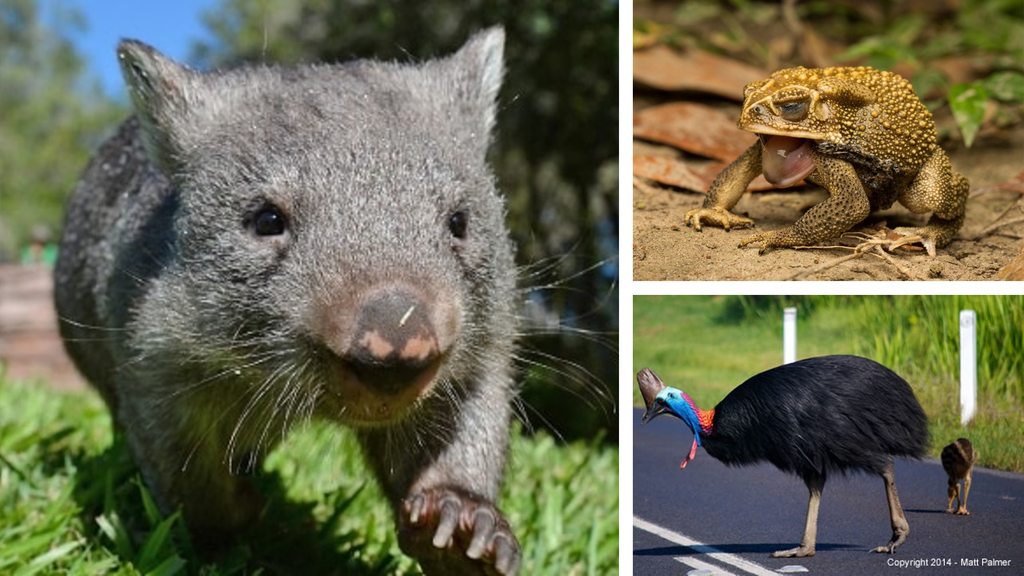

## Invasion is a process, not just a label

- **Introduced**
  - transported beyond natural range
- **Established**
  - self-sustaining population forms
- **Spreading**
  - population expands geographically
- **Invasive**
  - spread is accompanied by ecological or economic harm

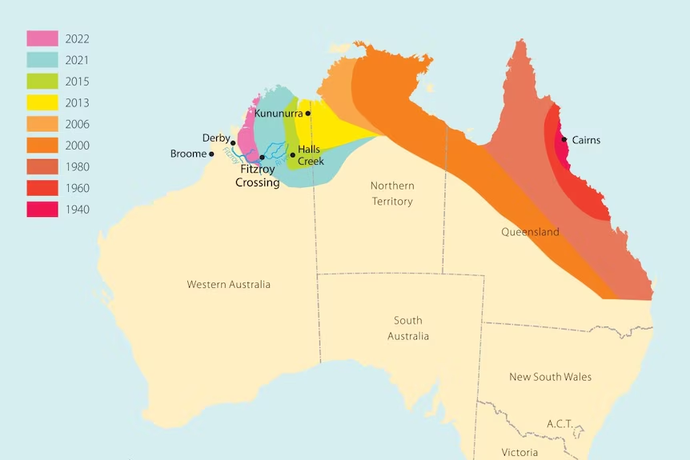

## Management dilemmas: what exactly are we trying to conserve?

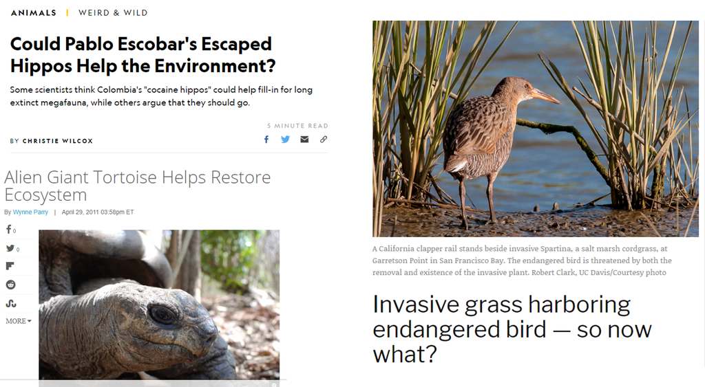

## Where: Species diversity generally declines from the tropics

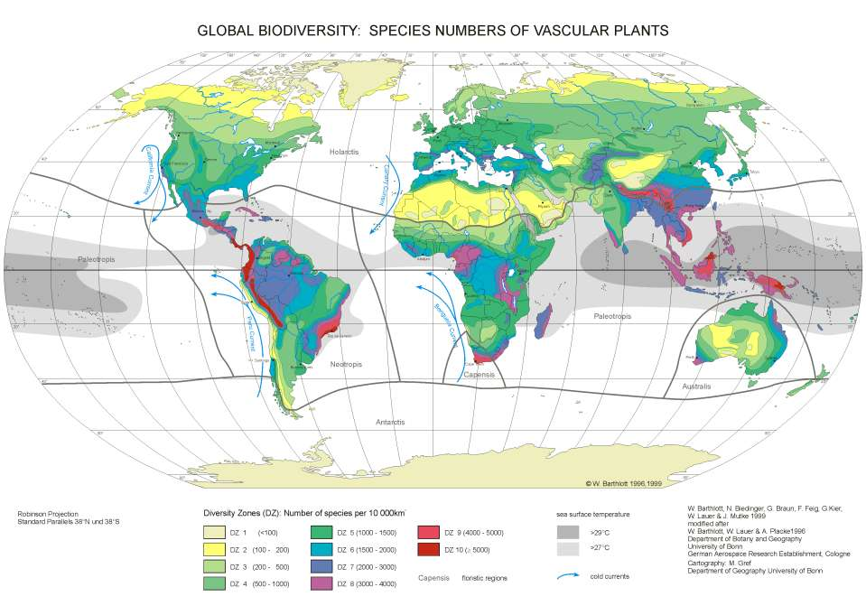

## Why are the tropics so diverse?

- **The pattern is clear, but the explanation is not singular**
- **Major drivers include:**
  - More energy/productivity can support more species
  - Greater habitat heterogeneity creates more niches
  - Long-term climatic stability promotes persistence and diversification
- **Take home: broad diversity gradients reflect both ecological and evolutionary processes**

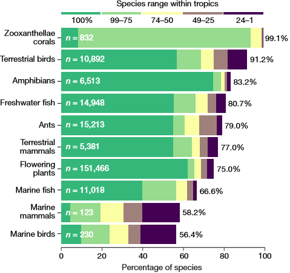

## Ecoregions: where biodiversity hotspots exist

**Diversity in the tropics is a broad global pattern—not a rule. High biodiversity and high endemism occur outside the tropics because of isolation, topography, evolutionary history, or unusual environments.**

[figure not shown]

## Hotspots: How can mountains create biodiversity?

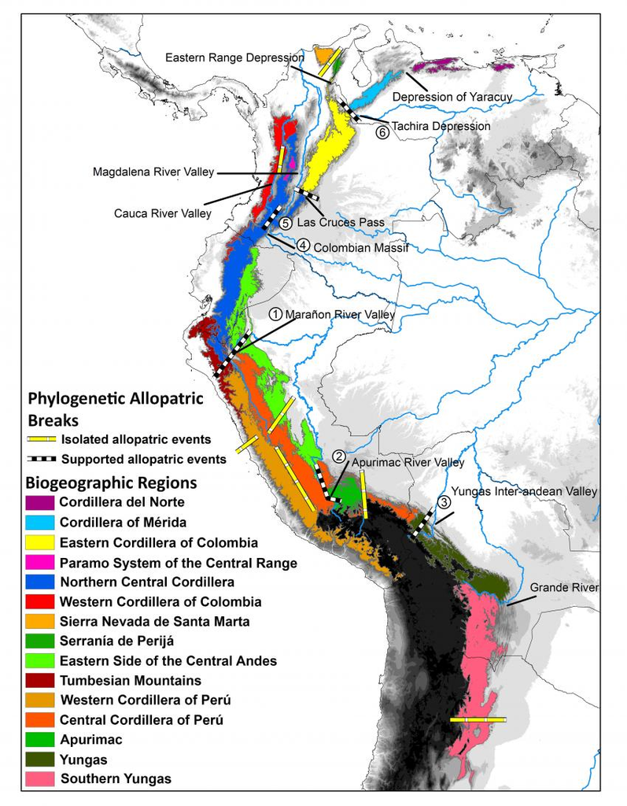

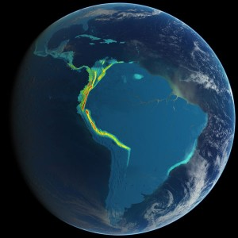

**Andean uplift created environmental heterogeneity, barriers to dispersal, and isolated habitats that promoted allopatric speciation and high endemism.**

## Hotspots: Endemic species of Madagascar

**PRACTICE: What factors contribute to the 90% endemism of Madagascar species?**

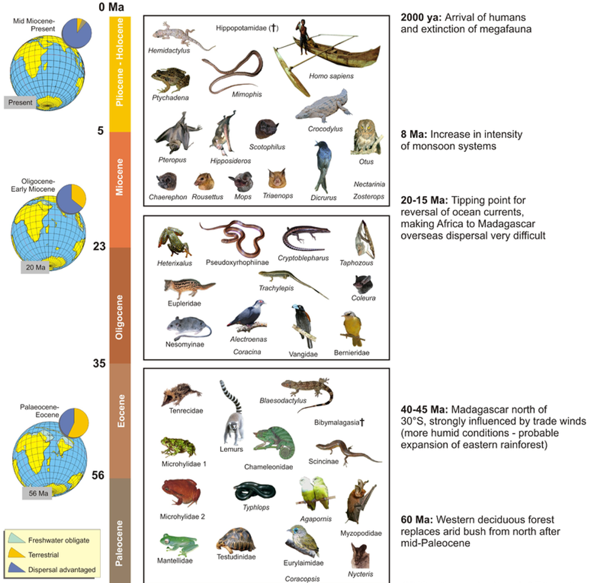

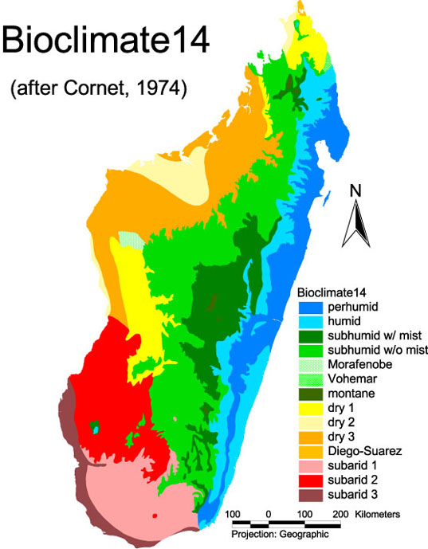

## Threats to biodiversity are additive and synergistic

- **Habitat loss and fragmentation**
  - smaller populations, isolation, reduced gene flow
- **Climate change**
  - range shifts, altered disturbance regimes, phenological mismatch
- **Species interactions can be disrupted**
  - loss of pollinators, hosts, prey, or mutualists can cause secondary declines
- **Overexploitation and food web disruption**
  - removal of functionally important species restructures communities
- **Invasive species and biotic homogenization**
  - replacement of distinct native communities by widespread generalists
- **Genetic erosion**
  - population bottlenecks reduce adaptive potential before species extinction occurs

**These threats rarely act independently — multiple stressors can interact and amplify biodiversity loss**

## Threats to biodiversity

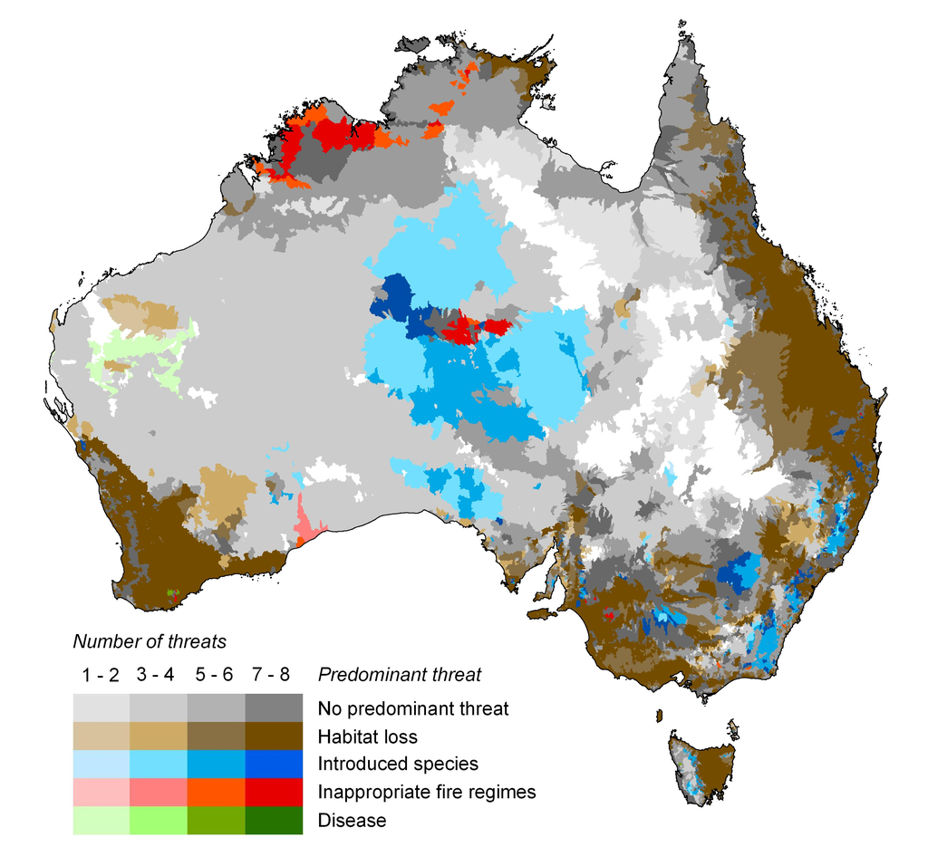

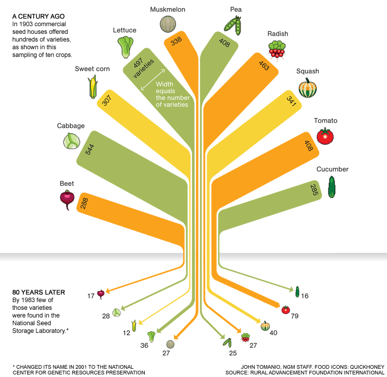

## Humans drive species redistribution

- **Human movement of organisms overcomes biogeographic barriers**
- **Shipping, trade, travel, and intentional introductions accelerate spread**
- **Aquatic systems are especially vulnerable**
- **This redistribution is a major driver of invasive species problems**

[figure not shown]

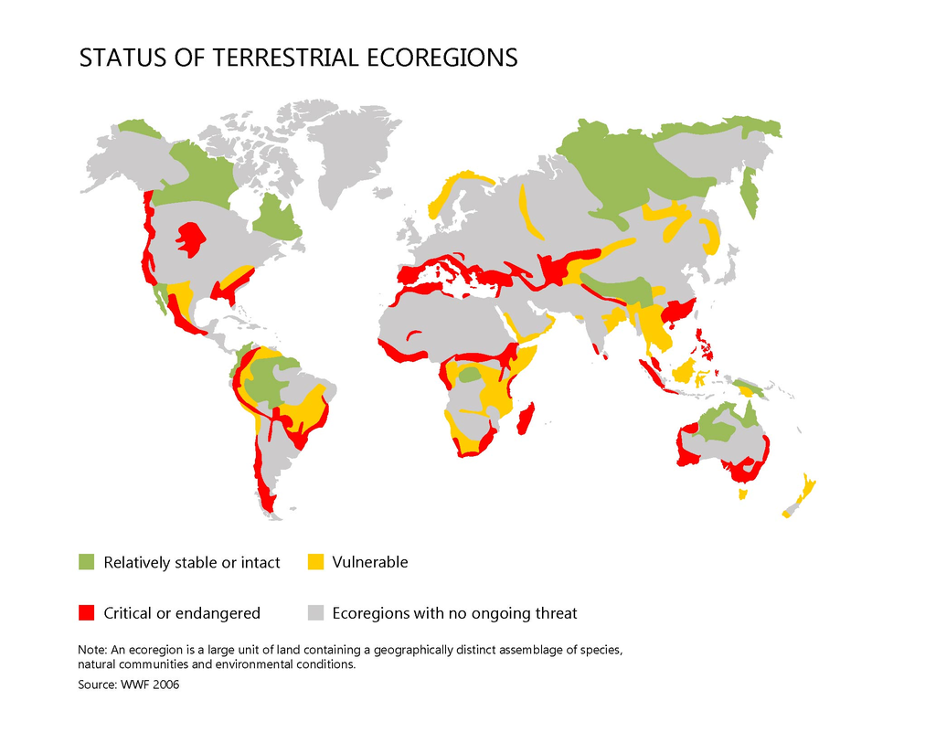

## Habitat loss, species-area relationships, and extinction debt

- **Larger areas tend to support more species**
  - S = cA<sup>z</sup>, where \(S\) is species richness and \(A\) is area.
- **Habitat loss therefore predicts species loss**
- **Extinction debt**
  - species may persist for a time after habitat is reduced
  - but eventual losses are still expected
- **Thus, lags exist between land-use change and biodiversity decline**

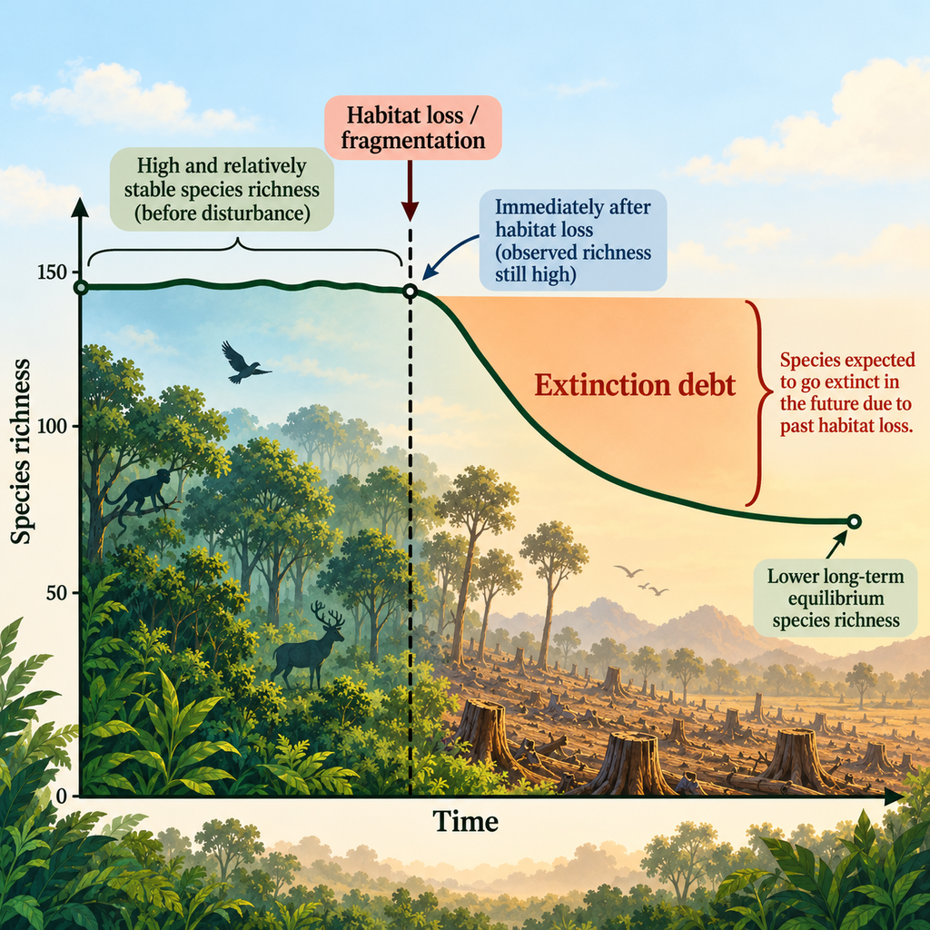

## Living Planet Index: population abundance is declining globally

- **Tracks changes in wild vertebrate population abundance**
  - 35,803 populations; 5,790 species
- **Average population abundance declined 73% since 1970**
  - freshwater populations: -85%
- **This is not a measure of species extinction**
  - warning signal of population decline
- **Trends are not universal**
  - some populations are stable or recovering

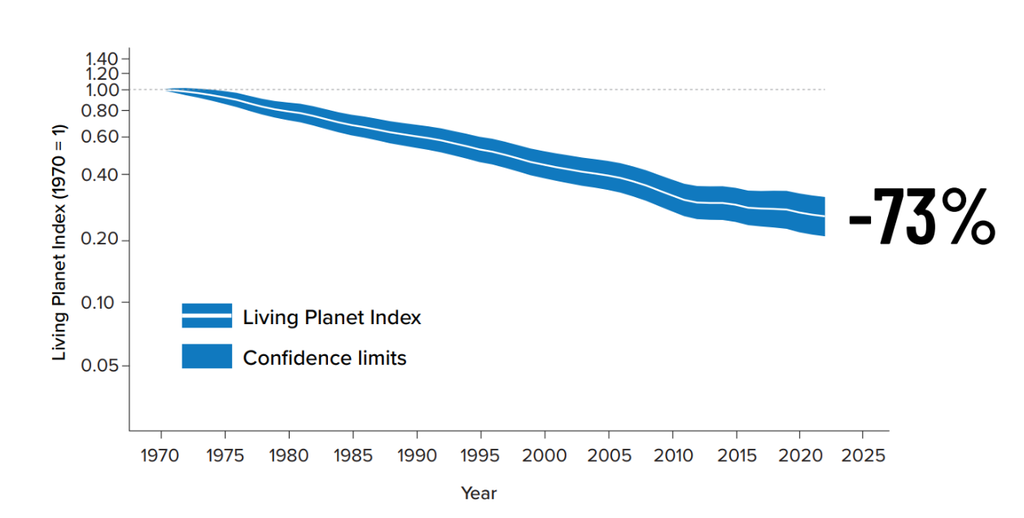

## Are we experiencing a new mass extinction?

- **Background extinction is a natural part of evolution**
  - <2 extinctions per million species per year
- **Current extinction rates are much higher**
  - estimated at 10-100s of times above long-term background rates
  - rates are still accelerating
- **Threatened does not mean doomed**
  - reducing pressures, protecting habitat, and restoring populations can prevent future extinctions

[figure not shown]

## Testable concepts

- **Biodiversity has multiple dimensions and scales**
  - species, functional, and genetic diversity; alpha, beta, and gamma diversity
- **Measuring biodiversity requires more than counting species**
  - richness, evenness, diversity indices, and the limits of those metrics
- **Biodiversity patterns reflect ecological and evolutionary processes**
  - latitudinal gradients, hotspots, endemism, isolation, and speciation
- **Human activities reshape biodiversity**
  - habitat loss, invasive species, homogenization, extinction risk, and extinction debt